# 4) Example of DBV-SBV models for varietal mixtures in a microplot-based design

T. Flutre

14/06/2026

Abstract

This document aims at simulating data with a DBV-SBV model for varietal mixtures (microplot-based design), fitting it, and checking the estimates.

# 1 Preamble

Dependencies:

```r
suppressPackageStartupMessages(library(plantmix))
suppressPackageStartupMessages(library(ggplot2))
```

# 2 Simulate data

```r
set.seed(12345)
```

## 2.1 Simulate the genotypes

### 2.1.1 Set the dimensions

```r
nbGenos <- 200
levGenos <- sprintf(fmt=paste0("g%0", floor(log10(nbGenos))+1, "i"),
                    1:nbGenos)

nbSnps <- 1000
levSnps <- sprintf(fmt=paste0("s%0", floor(log10(nbSnps))+1, "i"),
                   1:nbSnps)
```

### 2.1.2 SNP genotypes

```r
nb_pops <- 10
weak_div_pops <- diag(nb_pops)
weak_div_pops[upper.tri(weak_div_pops)] <- 0.9
weak_div_pops[lower.tri(weak_div_pops)] <- weak_div_pops[upper.tri(weak_div_pops)]
tmp <- rep(nbGenos / nb_pops, nb_pops - 1)
tmp <- c(tmp, nbGenos - sum(tmp))
snpGenos <- simulGenosDoseStruct(nb_genos=tmp,
                                 nb_snps=nbSnps,
                                 div_pops=weak_div_pops,
                                 geno_IDs=levGenos,
                                 snp_IDs=levSnps)
dim(snpGenos)
```

```
## [1]  200 1000
```

```r
snpGenos[1:3,1:4]
```

```
##      s0001 s0002 s0003 s0004
## g001     1     1     1     1
## g002     1     0     1     1
## g003     0     1     2     0
```

```r
table(snpGenos)
## snpGenos
##     0     1     2
## 61799 80252 57949
```

### 2.1.3 Additive genetic relationships

For simplicity, the first estimator of VanRaden (2008) is used, that assumes linkage equilibrium and Hardy-Weinberg equilibrium.

```r
snpAFs <- colSums(snpGenos) / (2 * nrow(snpGenos))
GRM <- estimGRM(snpGenos, snpAFs)
GRM <- as.matrix(Matrix::nearPD(GRM)$mat)
```

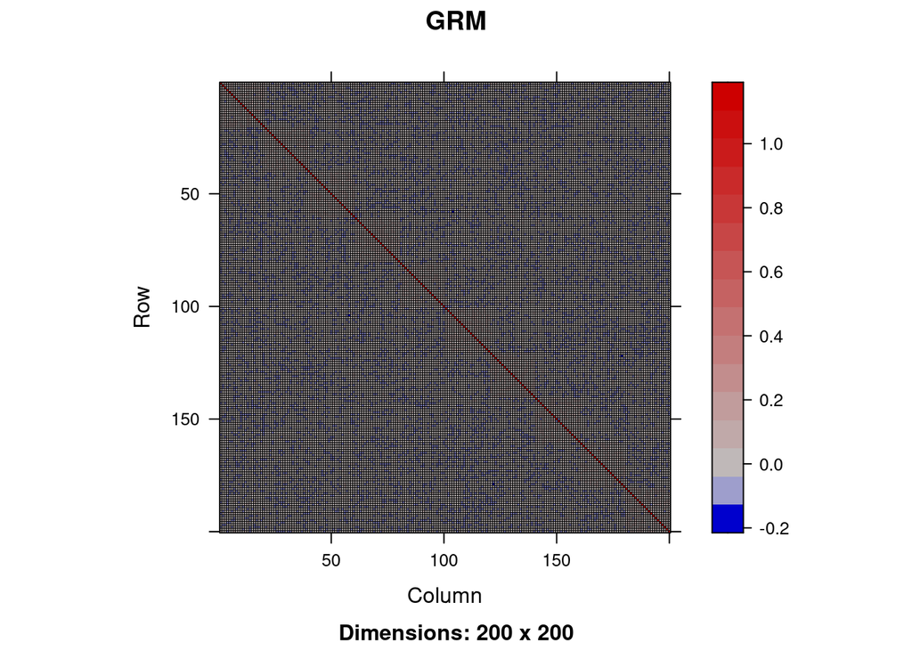

```r
image(Matrix(GRM), main="GRM")
```

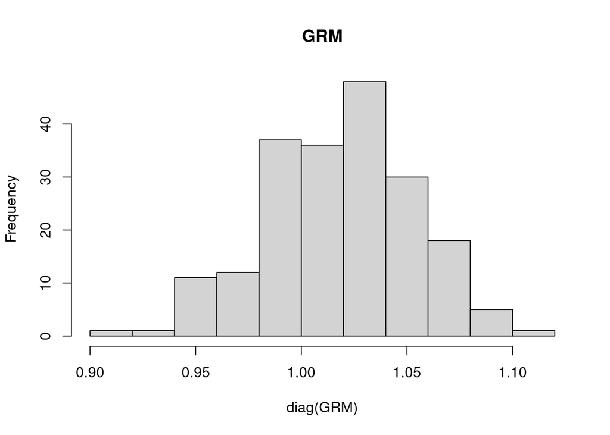

```r
hist(diag(GRM), main="GRM")
```

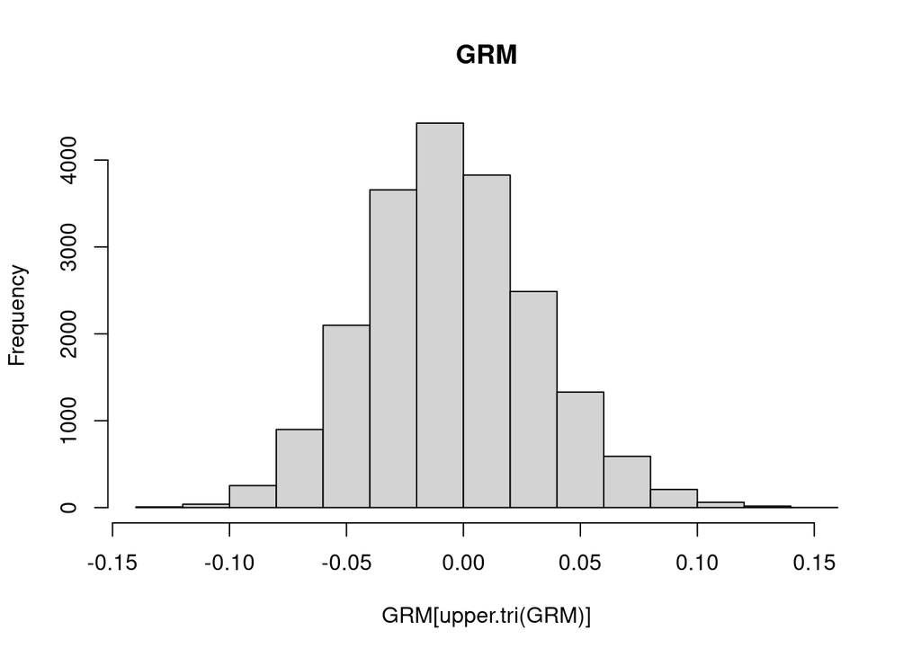

```r
hist(GRM[upper.tri(GRM)], main="GRM")
```

## 2.2 Simulate the phenotypes

In this vignette, binary varietal mixtures (of equal proportions) are assembled from this panel of 200 genotypes. Only 1000 mixtures are observed, among all 1.99^{4} possible ones, i.e., approximately 5%.

- The incomplete (sparse) design is optimized so that it is balanced: all genotype are observed in the same number of mixtures.
- The field trial contains these mixtures as well as monovarietals, and is organized as a randomized complete block design.

The yield data are generated according to the following equations, using the vec operator:

- varietal mixtures: $vec(Y_{mix}) = X_{mix} \, \boldsymbol{\beta}_{mix} + Z_{DS,mix} \, \boldsymbol{vec(BV_{DS})} + Z_{D{\times}S} \, \boldsymbol{vec(DBV{\times}SBV)} + \boldsymbol{\epsilon}_{mix}$
- monovarietals (“pure” stands): not (yet) simulated

Notations:

- $\boldsymbol{y}_{mix} := vec(Y_{mix})$ with $Y_{mix}$ being the yield matrix with one row per microplot and two columns, one per genotype in the mixtures
- $\boldsymbol{\beta}_{mix}$: vector of fixed effects (blocks)
- $BV_{DS} \sim \mathcal{N}(O, K, \Sigma_{DS})$
  - $BV_{DS}$: matrix whose first column contains the DBVs and second column the SBVs
  - $O$: matrix of zeroes of the same dimensions as $BV_{DS}$
  - $K$: genetic similarity (kinship) matrix between genotypes
  - $\Sigma_{DS}$: genetic covariance matrix between DBVs and SBVs
- $DBV{\times}SBV \sim \mathcal{N}(O, \; \sigma_{D{\times}S} \, K, \; \sigma_{D{\times}S} \, K)$
  - $DBV{\times}SBV$: matrix of DBV-SBV interactions, with focals in rows and neighbors in columns
  - $\sigma_{D{\times}S}^2$: variance component of DBV-SBV interactions
- $\boldsymbol{\epsilon}_{mix} := vec(E_{mix})$ where $E_{mix} \sim \mathcal{N}(O, \text{Id}, \Sigma_E)$
  - $O$: matrix of zeroes of the same dimensions as $E$
  - $\Sigma_E$: covariance matrix between errors within the same microplot

Assemble the mixtures by optimizing the design, and generate the phenotypes (for the moment, K is ignored when drawing DBVxSBV, and hence will be ignored in the inference, too, see below):

```r
out <- simulDBVSBVintraMicroplots(GRM, nbMixes = 1000)
names(out)
```

```
## [1] "design" "truth"  "datL"   "datW"
```

```r
tmp <- list2env(out, envir = environment())
```

Plot the design:

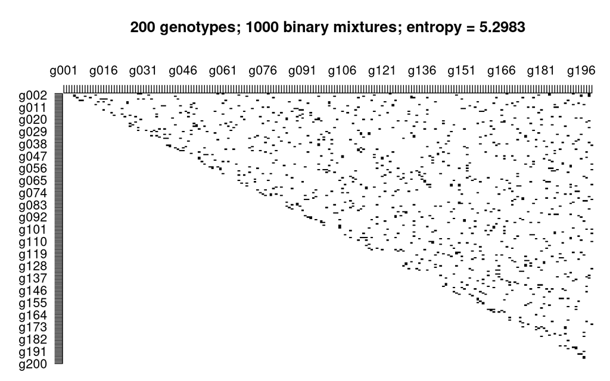

```r
design <- out$design
plotDesignVarMix(design$graph, levGenos, subplots = "diallel")
```

To check that the design is balanced, here is how to quickly check the number of mixtures in which each genotype is present:

```r
head(design$combs)
```

```
##   comp1 comp2
## 1  g004  g006
## 2  g006  g007
## 3  g006  g008
## 4  g003  g009
## 5  g004  g011
## 6  g009  g013
```

```r
mixtures <- getMixtureList(design$combs)
str(mixtures, list.len=6)
```

```
## List of 1000
##  $ 1   : chr [1:2] "g004" "g006"
##  $ 2   : chr [1:2] "g006" "g007"
##  $ 3   : chr [1:2] "g006" "g008"
##  $ 4   : chr [1:2] "g003" "g009"
##  $ 5   : chr [1:2] "g004" "g011"
##  $ 6   : chr [1:2] "g009" "g013"
##   [list output truncated]
```

```r
geno2mixes <- getMixturesPerGeno(mixtures)
geno2mixes[1:3]
```

```
## $g001
##  [1] "22"  "23"  "76"  "79"  "127" "325" "602" "853" "993" "996"
##
## $g002
##  [1] "26"  "96"  "294" "730" "873" "879" "890" "913" "950" "992"
##
## $g003
##  [1] "4"   "40"  "103" "194" "226" "277" "363" "914" "949" "998"
```

```r
table(sapply(geno2mixes, length))
```

```
##
##  10
## 200
```

# 3 Explore the data

```r
str(datW)
```

```
## 'data.frame':    2400 obs. of  15 variables:
##  $ ID              : Factor w/ 1200 levels "g001","g001+g029",..: 35 55 56 25 36 85 65 66 48 86 ...
##  $ geno_1          : Factor w/ 200 levels "g001","g002",..: 4 6 6 3 4 9 7 7 5 9 ...
##  $ geno_2          : Factor w/ 192 levels "g005","g006",..: 2 3 4 5 6 7 8 10 11 12 ...
##  $ props           : chr  "0.5+0.5" "0.5+0.5" "0.5+0.5" "0.5+0.5" ...
##  $ stand           : Factor w/ 2 levels "mono","mix": 2 2 2 2 2 2 2 2 2 2 ...
##  $ block           : Factor w/ 2 levels "A","B": 1 1 1 1 1 1 1 1 1 1 ...
##  $ true_fix_yield_1: num  36.3 36.3 36.3 36.3 36.3 ...
##  $ true_fix_yield_2: num  36.3 36.3 36.3 36.3 36.3 ...
##  $ true_gen_yield_1: num  0.21 -1.709 0.206 -4.118 -1.517 ...
##  $ true_gen_yield_2: num  0.564 2.031 3.386 4.401 2.916 ...
##  $ true_yield_1    : num  36.5 34.6 36.5 32.1 34.7 ...
##  $ true_yield_2    : num  36.8 38.3 39.6 40.7 39.2 ...
##  $ yield_1         : num  34.9 39.8 39.9 33.9 33.8 ...
##  $ yield_2         : num  38.2 36 35.8 48 38.8 ...
##  $ yield           : num  73.1 75.9 75.7 81.9 72.7 ...
```

```r
table(datW$stand)
```

```
##
## mono  mix
##  400 2000
```

```r
str(datL)
```

```
## 'data.frame':    4400 obs. of  14 variables:
##  $ focal         : Factor w/ 200 levels "g001","g002",..: 4 6 6 7 6 8 3 9 4 11 ...
##  $ neighbor      : Factor w/ 200 levels "g001","g002",..: 6 4 7 6 8 6 9 3 11 4 ...
##  $ ID            : Factor w/ 1200 levels "g001","g001+g029",..: 35 35 55 55 56 56 25 25 36 36 ...
##  $ geno_1        : Factor w/ 200 levels "g001","g002",..: 4 4 6 6 6 6 3 3 4 4 ...
##  $ geno_2        : Factor w/ 192 levels "g005","g006",..: 2 2 3 3 4 4 5 5 6 6 ...
##  $ props         : chr  "0.5+0.5" "0.5+0.5" "0.5+0.5" "0.5+0.5" ...
##  $ stand         : Factor w/ 2 levels "mono","mix": 2 2 2 2 2 2 2 2 2 2 ...
##  $ block         : Factor w/ 2 levels "A","B": 1 1 1 1 1 1 1 1 1 1 ...
##  $ propF         : num  0.5 0.5 0.5 0.5 0.5 0.5 0.5 0.5 0.5 0.5 ...
##  $ propN         : num  0.5 0.5 0.5 0.5 0.5 0.5 0.5 0.5 0.5 0.5 ...
##  $ true_fix_yield: num  36.3 36.3 36.3 36.3 36.3 ...
##  $ true_gen_yield: num  0.21 0.564 -1.709 2.031 0.206 ...
##  $ true_yield    : num  36.5 36.8 34.6 38.3 36.5 ...
##  $ yield         : num  34.9 38.2 39.8 36 39.9 ...
```

```r
head(table(datL$focal, datL$stand, datL$block))
## , ,  = A
##
##
##        mono mix
##   g001    1  10
##   g002    1  10
##   g003    1  10
##   g004    1  10
##   g005    1  10
##   g006    1  10
##
## , ,  = B
##
##
##        mono mix
##   g001    1  10
##   g002    1  10
##   g003    1  10
##   g004    1  10
##   g005    1  10
##   g006    1  10
```

## 3.1 Yields

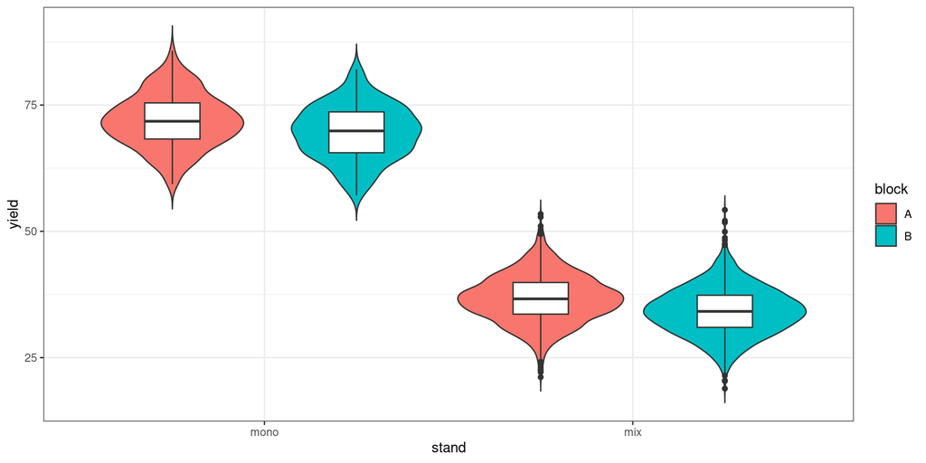

```r
pos <- position_dodge(1)
ggplot(datL) +
  aes(x = stand, y = yield) +
  geom_violin(aes(fill = block), trim = FALSE, position = pos) +
  geom_boxplot(aes(group = interaction(stand,block)), width = 0.3,
               position = pos) +
  theme_bw()
```

## 3.2 Relative yields of mixtures

Compute relative yields of mixtures (RYMs):

```r
RYMs <- list()
for(block in levels(datW$block)){
  RYMs[[block]] <- RYM(droplevels(datW[datW$block == block,]),
                       colIDcomps = "ID", sep = "+",
                       colProps = "props", colY = "yield")
}
RYMs <- do.call(rbind, RYMs)
RYMs <- droplevels(RYMs[RYMs$stand == "mix",])
```

Plot RYMs per block:

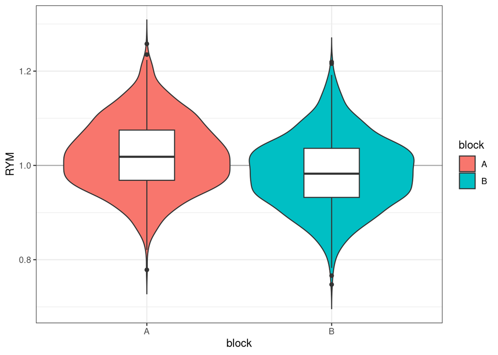

```r
ggplot(RYMs) +
  aes(x = block, y = RYM) +
  geom_hline(yintercept = 1, col = "darkgrey") +
  geom_violin(aes(fill = block), trim = FALSE) +
  geom_boxplot(width = 0.3) +
  theme_bw()
```

Plot RYMs per mixture:

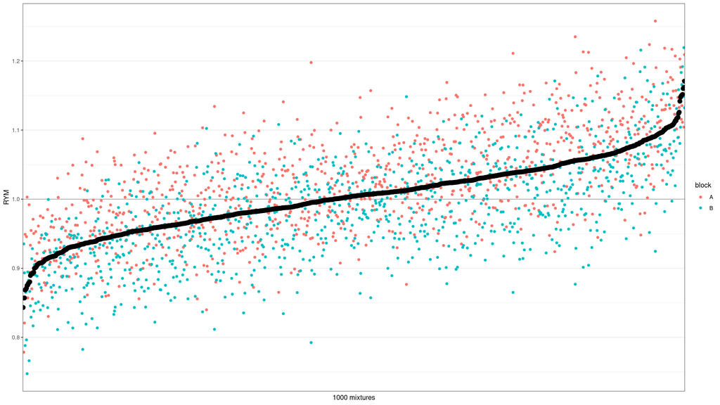

```r
tmp <- tapply(RYMs$RYM, RYMs$ID, mean)
RYMs$ID <- factor(as.character(RYMs$ID),
                  levels = names(sort(tmp)))
idx <- seq(1, nlevels(RYMs$ID), by = 10)
ggplot(RYMs) +
  aes(x = ID, y = RYM) +
  labs(x = paste0(nlevels(RYMs$ID), " mixtures")) +
  geom_hline(yintercept = 1, col = "darkgrey") +
  geom_point(aes(col = block)) +
  geom_point(data = data.frame(ID = names(sort(tmp)),
                               RYM = sort(tmp)),
             col = "black", size = 3) +
  guides(x =  guide_axis(angle = 45)) +
  ## scale_x_discrete(breaks = levels(RYMs$ID)[idx]) +
  theme_bw() +
  theme(
    axis.text.x  = element_blank(),
    axis.ticks.x = element_blank(),
    panel.grid.major.x = element_blank(),
    panel.grid.minor.x = element_blank()
  )
```

## 3.3 Relative yields

Compute relative yields (RYs):

```r
RYs <- list()
for(block in levels(datL$block)){
  RYs[[block]] <- RY(droplevels(datL[datL$block == block,]),
                     colIDstand = "ID", colIDfocal = "focal",
                     colProp = "propF", colY = "yield")
}
RYs <- do.call(rbind, RYs)
RYs <- droplevels(RYs[RYs$stand == "mix",])
```

Plot RYs per block:

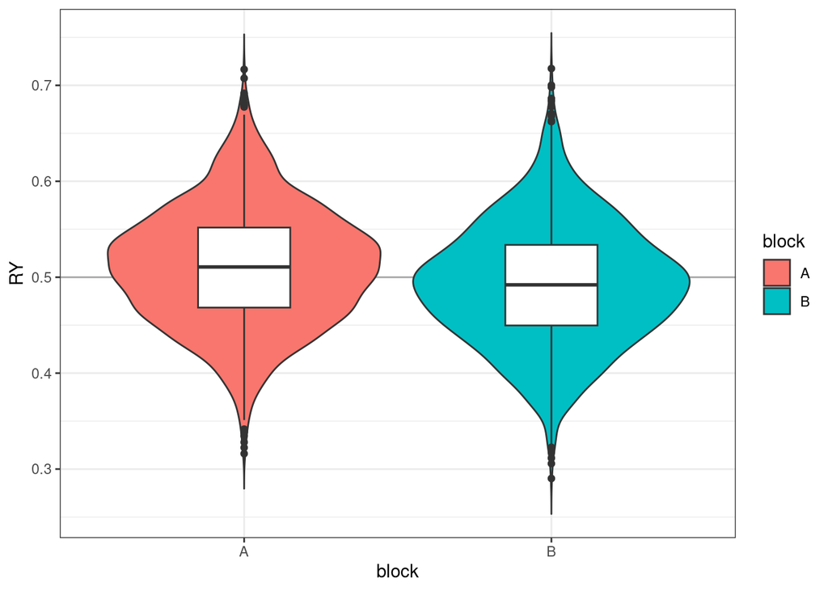

```r
ggplot(RYs) +
  aes(x = block, y = RY) +
  geom_hline(yintercept = 1/2, col = "darkgrey") +
  geom_violin(aes(fill = block), trim = FALSE) +
  geom_boxplot(width = 0.3) +
  theme_bw()
```

Plot RYs per focal genotype:

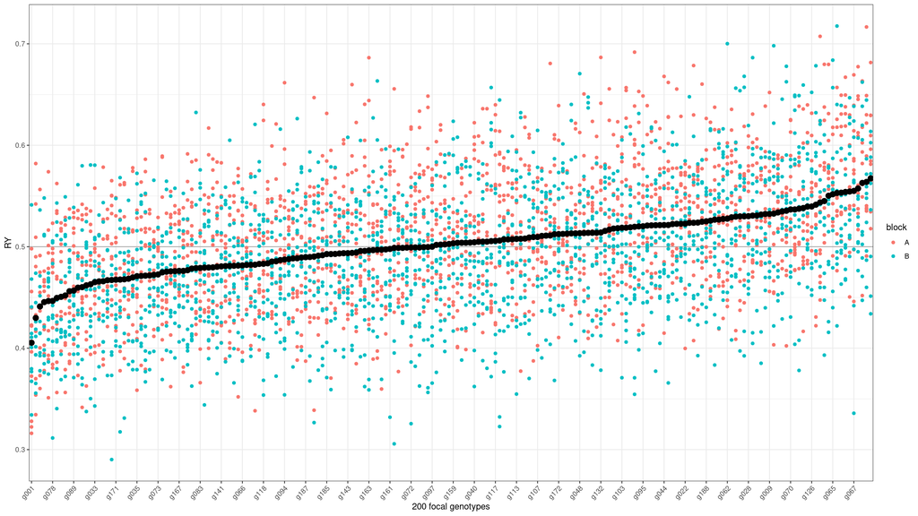

```r
tmp <- tapply(RYs$RY, RYs$focal, mean)
RYs$focal <- factor(as.character(RYs$focal),
                    levels = names(sort(tmp)))
idx <- seq(1, nlevels(RYs$focal), by = 5)
ggplot(RYs) +
  aes(x = focal, y = RY) +
  labs(x = paste0(nlevels(RYs$focal), " focal genotypes")) +
  geom_hline(yintercept = 1/2, col = "darkgrey") +
  geom_point(aes(col = block)) +
  geom_point(data = data.frame(focal = names(sort(tmp)),
                               RY = sort(tmp)),
             col = "black", size = 3) +
  guides(x =  guide_axis(angle = 45)) +
  scale_x_discrete(breaks = levels(RYs$focal)[idx]) +
  theme_bw()
```

# 4 Infer the parameters

## 4.1 Using mixtures only

### 4.1.1 Prepare the inputs

```r
idx_mix <- which(datL$stand == "mix")
datLmix <- droplevels(datL[idx_mix,])
listY <- list(y = datLmix$yield)

X <- model.matrix(~ 1 + block, data = datLmix, contrasts = list(block = "contr.sum"))

listZ <- list()
propNs <- as.list(datLmix$propN)
tmp <- mkZintraspe(datLmix,
  colIDfocal = "focal", colIDneighbors = "neighbor", sep = "+",
  colPfocal = "propF", prop_neighbors = propNs,
  genos = levels(datLmix$focal)
)
listZ$Z_DS <- cbind(tmp$Z_D, tmp$Z_S)

props <- Map(function(i) {
  setNames(
    unlist(datLmix[i, c("propF", "propN")]),
    as.character(unlist(datLmix[i, c("focal", "neighbor")]))
  )
}, 1:nrow(datLmix))
Z_DxS <- mkZintraspe_DxS(datLmix, props,
  colIDfocal = "focal", colIDneighbors = "neighbor", sep = "+",
  skipUnusedCols = TRUE
)
## listZ$Z_DxS <- Z_DxS

listVCov <- list(K = GRM[levels(datL$focal), levels(datL$focal)])
```

### 4.1.2 Fit the model

```r
system.time(
    fit <- fitDBVSBVintra(listY = listY,
                          X = X,
                          listZ = listZ,
                          listVCov = listVCov,
                          lOptions = list(iter.max = 20),
                          REML = TRUE, verbose = FALSE))
```

```
##    user  system elapsed
##  19.317   0.044  19.367
```

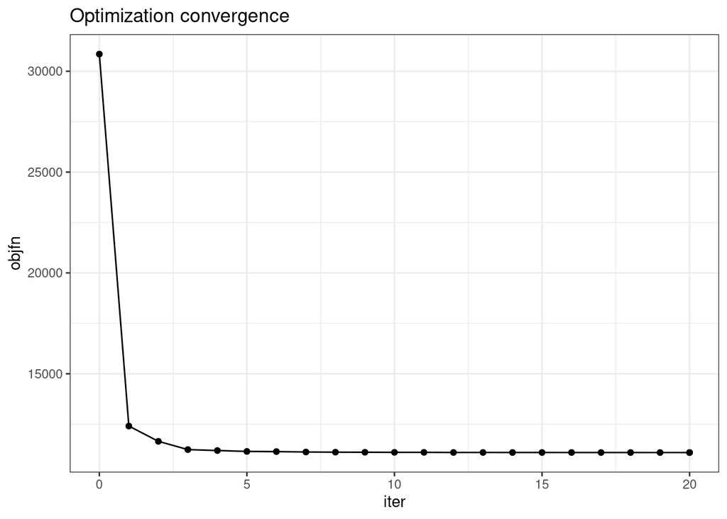

```r
ggplot(fit$trace) + aes(x = iter, y = objfn) +
  geom_point() + geom_line() + labs(title = "Optimization convergence") +
  theme_bw()
```

### 4.1.3 Checks

### 4.1.4 Fixed effects

```r
checks <- data.frame(
  param = rownames(fit$beta),
  truth = truth$blTrueContrs_mix,
  fit$beta,
  row.names = NULL,
  check.names = FALSE
)
checks$nBE <- normBiasError(checks$Estimate, checks$truth)
print(checks)
```

```
##         param     truth  Estimate Std. Error   z value    Pr(>|z^2|)        nBE
## 1 (Intercept) 35.000000 35.430253  0.0522177 678.51039  0.000000e+00  1.2292945
## 2      block1  1.259489  1.248004  0.0522177  23.90001 3.061876e-126 -0.9118796
```

### 4.1.5 (Co)variances of random genetic effects

```r
if ("var_DxS" %in% names(fit)) {
  checks <- data.frame(
    param = c(rownames(fit$vcov_BV), "var_DxS"),
    truth = c(
      truth$var_DBV,
      truth$var_SBV,
      truth$cor_DBV_SBV,
      truth$var_DBVxSBV
    ),
    rbind(fit$vcov_BV, fit$var_DxS),
    row.names = NULL,
    check.names = FALSE
  )
} else {
  checks <- data.frame(
    param = rownames(fit$vcov_BV),
    truth = c(
      truth$var_DBV,
      truth$var_SBV,
      truth$cor_DBV_SBV
    ),
    fit$vcov_BV,
    row.names = NULL,
    check.names = FALSE
  )
}
checks$nBE <- normBiasError(checks$Estimate, checks$truth)
print(checks)
```

```
##     param  truth   Estimate Std. Error    z value   Pr(>|z^2|)        nBE
## 1 var_DBV 31.360 26.8115640 2.87501958   9.325698 1.102556e-20 -14.503941
## 2 var_SBV  6.272  6.2005894 0.90959599   6.816861 9.305127e-12  -1.138562
## 3  cor_BV -0.800 -0.7341821 0.04967031 -14.781106 1.939538e-49  -8.227237
```

```r
checks <- data.frame(
  param = c("var_err", "cor_err"),
  truth = c(truth$var_err,
            truth$cor_err),
  rbind(fit$var_err,
        ifelse("Cor_E" %in% names(fit),
               fit$Cor_E[2,], rep(NA, 4))),
  row.names = NULL,
  check.names = FALSE
)
checks$nBE <- normBiasError(checks$Estimate, checks$truth)
print(checks)
```

```
##     param    truth   Estimate Std. Error    z value Pr(>|z^2|)         nBE
## 1 var_err 13.02224 13.0842019  0.3132472 41.7695763  0.0000000   0.4758338
## 2 cor_err -0.20000 -0.1664183 -0.1664183 -0.1664183 -0.1664183 -16.7908621
```

### 4.1.6 Random genetic effects

```r
if ("var_DxS" %in% names(fit)) {
  checks <- data.frame(
      param = c(
          rep(c("DBV","SBV"), each = nrow(truth$BV)),
          rep("DBVxSBV", ncol(listZ$Z_DxS))
      ),
      truth = c(
          truth$BV[levels(datLmix$focal),],
          truth$vecDBVxSBV[colnames(listZ$Z_DxS)]
      ),
      rbind(
          fit$DBV,
          fit$SBV,
          fit$DBVxSBV
      ),
      row.names = NULL,
      check.names = FALSE
  )
  checks$param <- factor(checks$param,
                         levels = c("DBV", "SBV", "DBVxSBV")
                         )
} else {
  checks <- data.frame(
      param = rep(c("DBV","SBV"), each = nrow(truth$BV)),
      truth = c(truth$BV[levels(datLmix$focal),]),
      rbind(fit$DBV, fit$SBV),
      row.names = NULL,
      check.names = FALSE
  )
  checks$param <- factor(checks$param,
                         levels = c("DBV", "SBV"))
}
checks$nBE <- normBiasError(checks$Estimate, checks$truth)
print(tapply(1:nrow(checks), checks$param, function(idx){
  cor(checks$truth[idx], checks$Estimate[idx])
}))
```

```
##       DBV       SBV
## 0.9671248 0.8397493
```

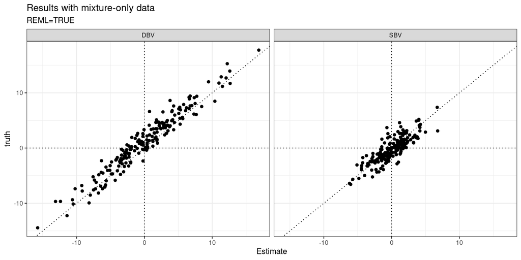

```r
ggplot(checks) +
  aes(x = Estimate, y = truth) +
  geom_hline(yintercept = 0, linetype = "dotted") +
  geom_vline(xintercept = 0, linetype = "dotted") +
  geom_abline(slope = 1, intercept = 0, linetype = "dotted") +
  geom_point() +
  labs(
    title = "Results with mixture-only data",
    subtitle = paste0("REML=", fit$REML)
  ) +
  theme_bw() +
  facet_wrap(~ param)
```

## 4.2 Using both monovarietals and mixtures

TODO

# 5 Appendix

```r
t1 <- proc.time()
t1 - t0
```

```
##    user  system elapsed
##  46.795   0.332  47.088
```